```python
import numpy as np
import matplotlib.pyplot as plt
import pandas as pd
```

# Title: Homework 3

# Author: Mason Wheeler

## 1. Linear Time-Invariant Systems

To obtain the response of the LTI system to the input signals 𝑥2(𝑡) and 𝑥3(𝑡), we will make use of the linearity and time-invariance properties of the system.

1c. 𝑥2(𝑡) is obtained from 𝑥1(𝑡) by subtracting signal 𝑎(𝑡) = 1 for 2 <= 𝑡 <= 4 and 0 elsewhere. Then, if we apply the LTI system to 𝑥1(𝑡) and 𝑎(𝑡), we can add up the corresponding outputs to obtain the response to 𝑥2(𝑡).

1d. Similarly, 𝑥3(𝑡) is obtained from 𝑥1(𝑡) by adding signal 𝑏(𝑡) = 1 for -1 <= 𝑡 <= 0 and 𝑏(𝑡) = 1 for 1 <= 𝑡 <= 2, and 0 elsewhere. Again, we apply the LTI system to 𝑥1(𝑡) and 𝑏(𝑡), and add up the corresponding outputs to obtain the response to 𝑥3(𝑡).

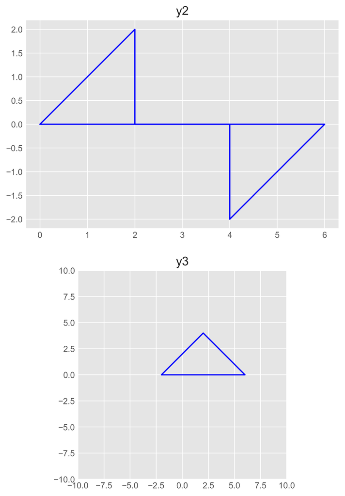

```python
fig, axs = plt.subplots(2, 1, figsize=(10, 10), dpi=400)
plt.style.use('ggplot')

plt.xlim(-10, 10)
plt.ylim(-10, 10)

# Define the coordinates of the triangles' vertices
triangle_1 = [(0, 0), (2, 2), (2, 0)]
triangle_2 = [(4, -2), (4, 0), (6, 0)]
horizontal_line = [(2, 0), (4, 0)]
triangle_3 = [(-2, 0), (2, 4), (6, 0)]

# Separate the coordinates for easier plotting
triangle_1_x, triangle_1_y = zip(*triangle_1)
triangle_2_x, triangle_2_y = zip(*triangle_2)
horizontal_line_x, horizontal_line_y = zip(*horizontal_line)

# Plot the triangles on the first axis
axs[0].plot(triangle_1_x + triangle_1_x[:1], triangle_1_y + triangle_1_y[:1], color = 'blue')
axs[0].plot(horizontal_line_x + horizontal_line_x[:1], horizontal_line_y + horizontal_line_y[:1], color = 'blue')
axs[0].plot(triangle_2_x + triangle_2_x[:1], triangle_2_y + triangle_2_y[:1], color = 'blue')

axs[0].set_aspect('equal', adjustable='box')


# Set a title
axs[0].set_title('y2')

triangle_3_x, triangle_3_y = zip(*triangle_3)

# Plot the triangles on the second axis
axs[1].plot(triangle_3_x + triangle_3_x[:1], triangle_3_y + triangle_3_y[:1], color = 'blue')

# Set the axis to have equal aspect ratio
axs[1].set_aspect('equal', adjustable='box')

# Set a title
axs[1].set_title('y3')



# Display the graph
plt.show()
```

### 2. Integrals involving the unit impulse signal

a) $\int_{-1}^{7} \delta(t - 5) dt$

Using the sifting property of the delta function, the integral equals 1 when the limits of integration include 5:

$$\int_{-1}^{7} \delta(t - 5) dt = 1$$

b) $\int_{\frac{\pi}{2}}^{\pi} \sin t \delta \left(t - \frac{\pi}{4}\right) dt$

Using the sifting property of the delta function:

c) $\int_{-2}^{5} e^{-t^2} \delta(t + 1) dt$

Using the sifting property of the delta function:

$$\int_{-2}^{5} e^{-t^2} \delta(t + 1) dt = e^{-(1)^2} = e^{-1}$$

d) $\int_{-\infty}^{\infty} (t^2 + 2t) \delta(2t - 1) dt$

We can use the change of variables $\tau = 2t - 1$, which gives us $t = \frac{\tau + 1}{2}$, and $dt = \frac{1}{2} d\tau$:

$$\int_{-\infty}^{\infty} \left(\frac{\tau + 1}{2}\right)^2 + 2\left(\frac{\tau + 1}{2}\right) \delta(\tau) \frac{1}{2} d\tau$$

Using the sifting property of the delta function:

### 3. Impulse responses of LTI systems

a) $T[x[n]] = -\frac{1}{5}x[n - 1] - \frac{1}{4}x[n] + \frac{1}{2}x[n + 1]$

To find the impulse response $h[n]$, we need to compute the system's response to the unit impulse signal $\delta[n]$:

$$h[n] = T[\delta[n]] = -\frac{1}{5}\delta[n - 1] - \frac{1}{4}\delta[n] + \frac{1}{2}\delta[n + 1]$$

b) $T[x(t)] = \int_{-1}^{2} x(t + 1 - \tau) d\tau$

To find the impulse response $h(t)$, we need to compute the system's response to the unit impulse signal $\delta(t)$:

$$h(t) = T[\delta(t)] = \int_{-1}^{2} \delta(t + 1 - \tau) d\tau$$

Using the sifting property of the delta function, we have:

c) $T[x(t)] = \int_{-\infty}^{t} \sin(t - \tau) x(\tau) d\tau$

To find the impulse response $h(t)$, we need to compute the system's response to the unit impulse signal $\delta(t)$:

$$h(t) = T[\delta(t)] = \int_{-\infty}^{t} \sin(t - \tau) \delta(\tau) d\tau$$

Using the sifting property of the delta function, we have:

$$h(t) = \sin(t)$$

### 4. Overall System Impulse Response and Output

(a) First, we can find the impulse response of the system composed of S1 and S2 by convolving their individual impulse responses:

$h_{12}[n] = h_1[n] * h_2[n] = \delta[n - 1] * 2\delta[n] = 2\delta[n - 1]$

Next, we can find the impulse response of the entire system by convolving the result from the previous step with the impulse response of S3:

$h[n] = h_{12}[n] * h_3[n] = 2\delta[n - 1] * 5\delta[n - 2] = 10\delta[n - 3]$

Therefore, the overall system impulse response is:

$h[n] = 10\delta[n - 3]$

(b) To find the output y[n], we can convolve the input signal x[n] with the system impulse response h[n]:

$y[n] = x[n] * h[n] = \sin(\frac{\pi}{4}n + 1)u[n] * 10\delta[n - 3]$

Using the convolution property, we get: $y[n] = 10\sin(\frac{\pi}{4}(n - 3) + 1)u[n - 3]$

Therefore, the output y[n] is:

$y[n] = \begin{cases} 0, & n < 3 \\ 10\sin(\frac{\pi}{4}(n - 3) + 1), & n \ge 3 \end{cases}$

### 5. Convolution of Input Signal and Impulse Response

Given input signal x[n] and impulse response h[n]:

$x[n] = u[n - 1]$

$h[n] = 2^{-n}u[n]$

We need to find the output y[n] = x[n] * h[n]. To do this, we'll perform convolution:

$y[n] = \sum_{k=-\infty}^{\infty} x[k] \cdot h[n - k]$

For the given x[n], x[k] is nonzero only when k >= 1. For the given h[n], h[n - k] is nonzero only when n - k >= 0, which implies k <= n. Thus, we only need to sum over the values of k for which 1 <= k <= n.

$y[n] = \sum_{k=1}^{n} x[k] \cdot h[n - k]$

Since $x[k] = u[k - 1]$, we have $x[k] = 1$ for $k \ge 1$, and $h[n - k] = 2^{-(n - k)}u[n - k]$, we have $h[n - k] = 2^{-(n - k)}$ for $n - k \ge 0$.

Thus, we have:

$y[n] = \sum_{k=1}^{n} 1 \cdot 2^{-(n - k)}$

$y[n] = \sum_{k=1}^{n} 2^{-(n - k)}$

$y[n] = \sum_{k=1}^{n} 2^{k - n}$

Therefore, the output y[n] is:

$y[n] = \begin{cases} 0, & n < 1 \\ \sum_{k=1}^{n} 2^{k - n}, & n \ge 1 \end{cases}$